# Do Preventive Financial Behaviors Improve Financial Resilience?

Author

Romaissae Kharrab

Published

April 1, 2026

```r
rm(list=ls()) #This line of code cleans the environment

# Load libraries (or packages):
library(tidyverse) #This library contains the most important functions you'll be using, download it everytime
library(patchwork)  # This library is very useful to combine multiple plots into one
#Load the dataset:
dataset = read_csv("findex_microdata_2025.csv")
```

## Introduction

The Covid-19 crisis showed that many households are financially vulnerable. During this period, many people lost their jobs or experienced a decrease in income. At the same time, daily expenses did not disappear. As a result, some households found it difficult to cover basic needs such as food, housing or healthcare. In some cases, even a small drop in income created serious financial stress.

However, households did not react in the same way. Some were able to manage the situation and maintain a certain level of stability. Others, on the contrary, saw their financial situation deteriorate very quickly. This difference is important. It suggests that some households are better prepared than others to deal with unexpected shocks.

One possible explanation is the role of preventive financial behaviors. For example, saving money in advance or having insurance can help households face difficult periods. These tools can provide additional resources when income falls. They can also help households avoid reducing their consumption too quickly or falling into financial difficulty.

This leads to the main question of this study: to what extent do preventive financial behaviors help households become more resilient to income shocks? This question is important not only from an academic point of view, but also for public policy. It is directly related to financial inclusion, social protection, and the role of financial tools in supporting households in times of crisis.

Based on this discussion, we propose the following hypothesis:

H1: households that adopt preventive financial behaviors, such as saving or having insurance, are more resilient to income shocks.

This hypothesis is based on a simple idea. When households save money, they build a financial buffer that can be used in difficult times. This allows them to continue covering their basic needs even if their income falls.

At the same time, insurance plays a different but complementary role. It protects households against specific risks, such as illness, accidents or loss of income. When such events occur, insurance can provide financial compensation. This reduces the need to cut consumption sharply. In this sense, insurance helps households manage uncertainty. It allows them to face unexpected events without bearing the full financial cost.

On the contrary, households without savings or insurance have fewer options when a shock occurs. They may need to reduce their consumption quickly or rely on external support, which increases their vulnerability. For these reasons, we expect a positive relationship between preventive financial behaviors and financial resilience.

## Descriptive Statistics

The dataset used in this study comes from the Global Findex database (World Bank, 2025). It contains 144,090 observations and includes a wide range of variables related to financial inclusion, such as savings behavior, insurance usage, and the ability to cope with financial shocks. The data covers multiple countries across different regions of the world, including Africa, Asia, Europe, and Latin America. It provides harmonized information at the individual level, allowing for cross-country comparisons of financial behavior.

This study uses the variable fin24b to measure financial resilience because it shows how long a household can keep covering its expenses if it loses its main source of income. We chose this variable because it directly reflects the household’s ability to cope with an income shock.

```r
# Calculate the percentage of missing values in fin24b
library(knitr)
library(kableExtra)

kable(data.frame(
  Variable = "Financial Resilience",
  `Percentage of missing values` = round(mean(is.na(dataset$fin24b)) * 100, 2)
),
caption = "Table 1: Percentage of Missing Values for Financial Resilience") %>%
  kable_styling(full_width = FALSE, position = "center")
```

Table 1: Percentage of Missing Values for Financial Resilience

| Variable | Percentage.of.missing.values |
| --- | --- |
| Financial Resilience | 28.55 |

The percentage of missing values is relatively high (Table 1). Therefore, we choose to remove observations with missing values in fin24b for the analysis.

Since fin24b is a categorical variable with a limited number of ordered categories, the concept of outliers, which are values that are very different from the rest of the data, is not relevant in this case. All observed values here correspond to predefined response categories, rather than extreme or abnormal observations.

```r
library(tidyverse)
library(knitr)

# Recode + order directly
dataset <- dataset %>%
  mutate(
    fin24b_label = case_when(
      fin24b == 1 ~ "Less than two weeks",
      fin24b == 2 ~ "About one month",
      fin24b == 3 ~ "About two months",
      fin24b == 4 ~ "More than two months",
      TRUE ~ NA_character_
    ),
    fin24b_label = factor(
      fin24b_label,
      levels = c(
        "Less than two weeks",
        "About one month",
        "About two months",
        "More than two months"
      )
    )
  )

# Create table
fin24b_table <- dataset %>%
  filter(!is.na(fin24b_label)) %>%
  count(fin24b_label) %>%
  mutate(
    percent = round(100 * n / sum(n), 2)
  ) %>%
  arrange(fin24b_label)  # ensures correct order

# Display table
kable(
  fin24b_table,
  col.names = c("Expense coverage period", "Count", "Percentage"),
  caption = "Table 2: Distribution of households by ability to cover expenses after an income shock"
)
```

Table 2: Distribution of households by ability to cover expenses after an income shock

| Expense coverage period | Count | Percentage |
| --- | --- | --- |
| Less than two weeks | 18026 | 19.09 |
| About one month | 27801 | 29.44 |
| About two months | 17486 | 18.52 |
| More than two months | 31108 | 32.95 |

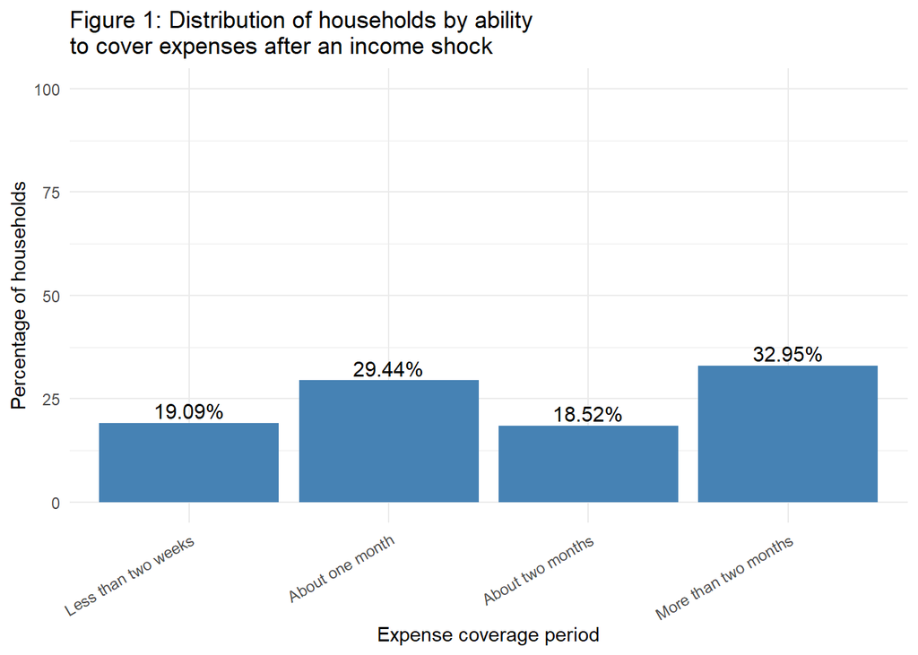

```r
# Visualize fin24b
ggplot(fin24b_table, aes(x = fin24b_label, y = percent)) +
  geom_col(fill = "steelblue") +
  geom_text(aes(label = paste0(percent, "%")),
            vjust = -0.3, size = 4) +
  labs(
    title = "Figure 1: Distribution of households by ability\nto cover expenses after an income shock",
    x = "Expense coverage period",
    y = "Percentage of households"
  ) +
  scale_y_continuous(limits = c(0, 100)) +
  theme_minimal() +
  theme(axis.text.x = element_text(angle = 30, hjust = 1))
```

Households do not all have the same level of financial resilience. The largest group can cover their expenses for more than two months after an income shock (32.95%), while 29.44% can do so for about one month. In contrast, 19.09% can cover their expenses for less than two weeks, which shows that many households are still financially vulnerable.

Regarding the explanatory variable, preventive financial risk management is measured using an index that goes from 0 to 1. This index is built as the average of two indicators that show financial protection actions taken before a shock happens, such as saving during the year and making regular insurance payments. We grouped these variables into one index to capture, in a broader way, how prepared households are for a possible loss of income.

```r
library(tidyverse)

# Recode the variables into binary values
dataset <- dataset %>%
  mutate(
    save_year = ifelse(fin18 == 1, 1,
                       ifelse(fin18 == 2, 0, NA)),

    insurance_payment = ifelse(fin19 == 1, 1,
                               ifelse(fin19 == 2, 0, NA))
  )


# Build the index as the average of the two variables

dataset <- dataset %>%
  mutate(
    preventive_risk_index = ifelse(
      is.na(save_year) |  is.na(insurance_payment),
      NA,
      (save_year + insurance_payment) / 2
    )
  )
```

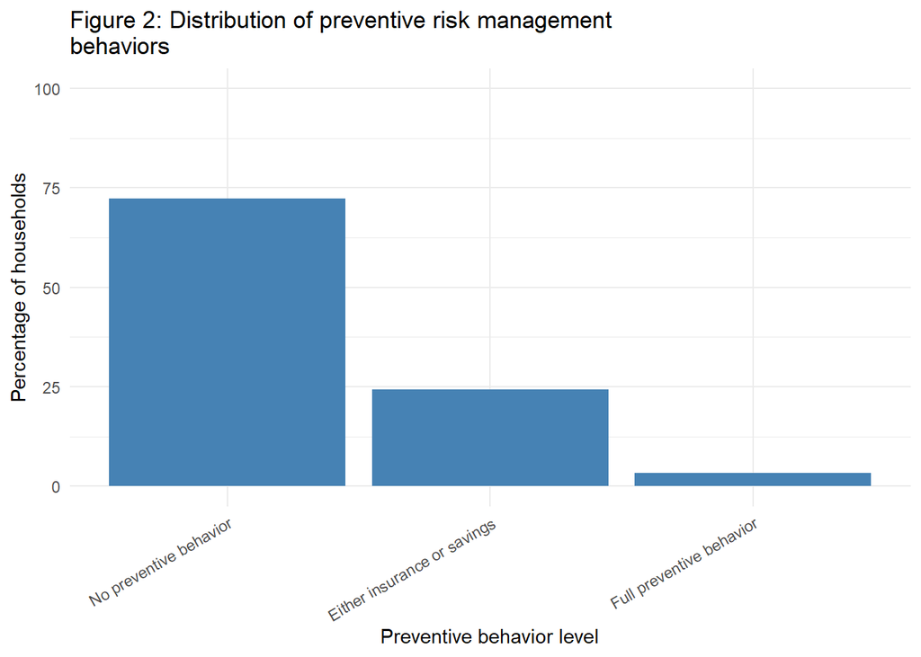

```r
index_table_clean <- dataset %>%
  # Exclude observations with missing values for the preventive risk index
  filter(!is.na(preventive_risk_index)) %>%

  mutate(
    # Recode the numeric index into meaningful preventive behavior categories
    preventive_label = case_when(
      preventive_risk_index == 0   ~ "No preventive behavior",
      preventive_risk_index == 0.5 ~ "Either insurance or savings",
      preventive_risk_index == 1   ~ "Full preventive behavior"
    ),

    # Set the category order to ensure a logical display in the graph
    preventive_label = factor(
      preventive_label,
      levels = c(
        "No preventive behavior",
        "Either insurance or savings",
        "Full preventive behavior"
      )
    )
  ) %>%

  # Count the number of households in each category
  count(preventive_label) %>%

  # Convert counts into percentages
  mutate(percent = 100 * n / sum(n))

# Plot percentages
ggplot(index_table_clean, aes(x = preventive_label, y = percent)) +
  geom_col(fill = "steelblue") +

  # Add title and axis labels
  labs(
    title = "Figure 2: Distribution of preventive risk management\nbehaviors",
    x = "Preventive behavior level",
    y = "Percentage of households"
  ) +
  scale_y_continuous(limits = c(0, 100)) +

  theme_minimal() +

  # Rotate x-axis labels to improve readability
  theme(
    axis.text.x = element_text(angle = 30, hjust = 1)
  )
```

The graph shows that most households have no preventive behavior, meaning they have neither insurance nor savings (Figure 2). A smaller share shows partial protection, meaning they rely on either insurance or savings, but not both. Only a very small proportion has full protection, which shows that very few households combine both insurance and savings.

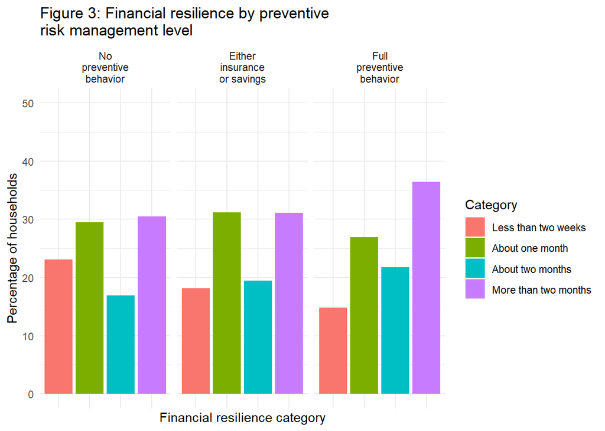

```r
library(tidyverse)

# Recode fin24b with labels (if not already done)
dataset <- dataset %>%
  mutate(
    fin24b_label = case_when(
      fin24b == 1 ~ "Less than two weeks",
      fin24b == 2 ~ "About one month",
      fin24b == 3 ~ "About two months",
      fin24b == 4 ~ "More than two months",
      TRUE ~ NA_character_
    ),
    # Set the order of categories (very important for the plot)
    fin24b_label = factor(
      fin24b_label,
      levels = c(
        "Less than two weeks",
        "About one month",
        "About two months",
        "More than two months"
      )
    ),
    preventive_label = case_when(
      preventive_risk_index == 0   ~ "No\npreventive\nbehavior",
      preventive_risk_index == 0.5 ~ "Either\ninsurance\nor savings",
      preventive_risk_index == 1   ~ "Full\npreventive\nbehavior"
    ),

    # Set the category order to ensure a logical display in the graph
    preventive_label = factor(
      preventive_label,
      levels = c(
        "No\npreventive\nbehavior",
        "Either\ninsurance\nor savings",
        "Full\npreventive\nbehavior"
      )
    )
  )


# Create proportions by index
plot_data <- dataset %>%
  filter(!is.na(fin24b_label), !is.na(preventive_label)) %>%
  count(preventive_label, fin24b_label) %>%
  group_by(preventive_label) %>%
  mutate(percent = 100 * n / sum(n)) %>%
  ungroup()

# Plot
ggplot(plot_data, aes(x = fin24b_label, y = percent, fill = fin24b_label)) +
  geom_col() +
  facet_wrap(~ preventive_label) +
  labs(
    title = "Figure 3: Financial resilience by preventive\nrisk management level",
    x = "Financial resilience category",
    y = "Percentage of households",
    fill = "Category"
  ) +
  scale_y_continuous(limits = c(0, 50), breaks = seq(0, 100, 10)) +

  theme_minimal() +
  theme(
    axis.text.x = element_blank(),
    axis.ticks.x = element_blank()
  )
```

The Figure 3 shows a clear link between preventive behavior and financial resilience. As we move from no preventive behavior to full preventive behavior, the share of households that can cover expenses for more than two months increases. At the same time, the share of households that can cover less than two weeks decreases. This means that households with no protection are more vulnerable, while those with both insurance and savings are better prepared for an income shock.

In order to better isolate the effect of preventive financial behaviors on financial resilience, we include age, education, income and gender as control variables. These variables are chosen because they can influence both financial resilience and preventive financial behaviors.

First, income plays a key role. Households with higher income are more likely to save or purchase insurance. As a result, they are also better able to cope with income shocks, since they have more resources to rely on. In addition, education is important. More educated individuals may have better financial knowledge. Therefore, they are more likely to adopt preventive behaviors such as saving or using insurance. At the same time, they may be better prepared to manage financial difficulties, which improves their resilience.

Moreover, age may affect both dimensions. Older individuals may have had more time to accumulate savings and gain financial experience. Consequently, they may be more likely to adopt preventive behaviors and better able to deal with shocks. Finally, gender can also play a role. Differences in access to financial services, employment opportunities or income levels may influence both the use of financial tools and the ability to cope with shocks.

Overall, these variables appear relevant at first glance. However, we will perform a model selection process to identify the most appropriate set of variables and ensure that the final model is well specified.

## Statistical Inference

To analyze the link between preventive financial behaviors and household resilience, we use a linear mixed regression. Linear regression is a statistical method that measures how much one variable explains another. It fits our case well for two reasons. First, our outcome variable, financial resilience, is measured on a scale that goes from “less than two weeks” to “more than two months”. This scale follows a clear and logical order, which allows us to treat it as a numeric variable. Second, our goal is to measure the effect of preventive behavior on this scale, which is exactly what linear regression does.

We use a “mixed” version of this model because our data covers several regions of the world. Two households living in the same region tend to be more similar to each other than two households living in different regions. The mixed model accounts for this by adding a specific effect for each region, which makes the results more accurate and more reliable.

### Model Assumptions Check

Before interpreting the results, we need to verify that the model meets the basic statistical assumptions. This step is important because if the assumptions are violated, the results may be unreliable.

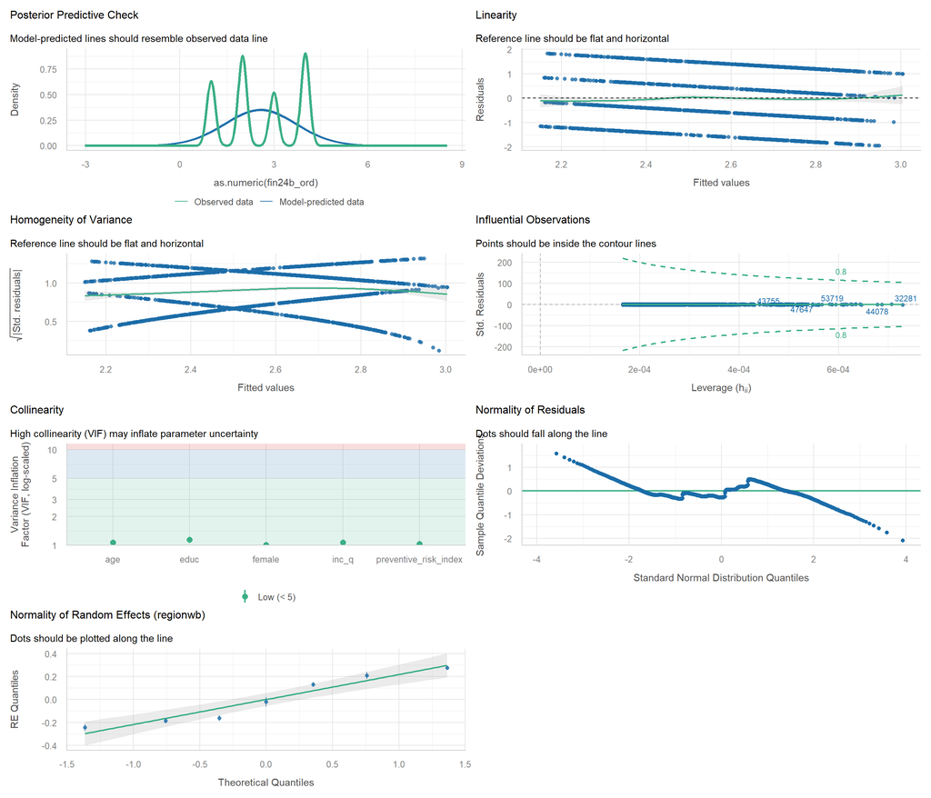

```r
library(lmerTest)
library(modelsummary)
library(performance)

# Create ordered outcome variable
dataset <- dataset %>%
  mutate(
    fin24b_ord = case_when(
      fin24b == 1 ~ 1,
      fin24b == 2 ~ 2,
      fin24b == 3 ~ 3,
      fin24b == 4 ~ 4,
      TRUE ~ NA_real_
    )
  )

# Convert categorical variables to factors
dataset <- dataset %>%
  mutate(
    female = as.factor(female),
    educ   = as.factor(educ),
    inc_q  = as.factor(inc_q)
  )

# Fit the full mixed model before variable selection
model_mixed <- lmer(
  as.numeric(fin24b_ord) ~ preventive_risk_index + age +
    female + educ + inc_q + (1 | regionwb),
  data = dataset,
)

# Check model assumptions
check_model(model_mixed)
```

On the collinearity side, all VIF values are well below 5. This means that the explanatory variables are not strongly related to each other, so multicollinearity is not a concern here. The normality of residuals plot shows that the dots deviate from the line at both ends. This kind of deviation is common when the outcome variable takes only a limited number of values. The last plot looks at the normality of random effects. The dots follow the line closely, which confirms that the regional effects are well-behaved and normally distributed.

Overall, the mild violations we observed are expected and are mainly driven by the discrete nature of the outcome variable. They do not seriously affect the validity of the results

### Model Selection

Once the model assumptions are verified, the next step is to identify which variables best explain financial resilience. We automatically compare all possible combinations of variables and rank them based on the AIC criterion. The model with the lowest AIC value and a delta equal to zero is considered the best model. This approach allows us to keep only the variables that genuinely contribute to explaining the outcome, and to avoid including unnecessary variables that could reduce the quality of the model.

```r
library(lmerTest)
library(modelsummary)
library(MuMIn)
library(knitr)

# Create ordered outcome variable
dataset <- dataset %>%
  mutate(
    fin24b_ord = case_when(
      fin24b == 1 ~ 1,
      fin24b == 2 ~ 2,
      fin24b == 3 ~ 3,
      fin24b == 4 ~ 4,
      TRUE ~ NA_real_
    )
  )

# Convert categorical variables to factors
dataset <- dataset %>%
  mutate(
    female = as.factor(female),
    educ   = as.factor(educ),
    inc_q  = as.factor(inc_q)
  )

# Remove missing values on model variables
dataset_clean <- dataset %>%
  filter(
    !is.na(fin24b_ord),
    !is.na(preventive_risk_index),
    !is.na(age),
    !is.na(female),
    !is.na(educ),
    !is.na(inc_q),
    !is.na(regionwb)
  )

# Fit the full mixed model with na.action = na.fail (required for dredge)
model_mixed <- lmer(
  as.numeric(fin24b_ord) ~ preventive_risk_index + age +
    female + educ + inc_q + (1 | regionwb),
  data = dataset_clean,
  na.action = na.fail
)

# Run dredge to compare all variable combinations
dredge_results <- dredge(model_mixed)
kable(dredge_results,
      caption = "Table 3: Comparison of different models explaining financial resilience")
```

Table 3: Comparison of different models explaining financial resilience

|  | (Intercept) | age | educ | female | inc_q | preventive_risk_index | df | logLik | AICc | delta | weight |
| --- | --- | --- | --- | --- | --- | --- | --- | --- | --- | --- | --- |
| 19 | 2.448425 | NA | + | NA | NA | 0.1754730 | 6 | -85177.77 | 170367.5 | 0.000000 | 9.609765e-01 |
| 27 | 2.487541 | NA | + | NA | + | 0.1806441 | 10 | -85177.61 | 170375.2 | 7.683255 | 2.062125e-02 |
| 23 | 2.443818 | NA | + | + | NA | 0.1741722 | 7 | -85180.78 | 170375.6 | 8.015027 | 1.746915e-02 |
| 20 | 2.432522 | 0.0003356 | + | NA | NA | 0.1757395 | 7 | -85184.32 | 170382.6 | 15.107402 | 5.037119e-04 |
| 31 | 2.482851 | NA | + | + | + | 0.1793944 | 11 | -85180.53 | 170383.1 | 15.531044 | 4.075580e-04 |
| 28 | 2.469949 | 0.0003774 | + | NA | + | 0.1810266 | 11 | -85183.98 | 170390.0 | 22.429416 | 1.294873e-05 |
| 24 | 2.428884 | 0.0003195 | + | + | NA | 0.1744849 | 8 | -85187.39 | 170390.8 | 23.250723 | 8.587808e-06 |
| 32 | 2.466239 | 0.0003611 | + | + | + | 0.1798187 | 12 | -85186.98 | 170398.0 | 30.424767 | 2.377162e-07 |
| 3 | 2.469078 | NA | + | NA | NA | NA | 5 | -85221.68 | 170453.4 | 85.824970 | 2.218490e-19 |
| 7 | 2.462037 | NA | + | + | NA | NA | 6 | -85223.83 | 170459.7 | 92.125444 | 9.504447e-21 |
| 17 | 2.507931 | NA | NA | NA | NA | 0.2037225 | 4 | -85228.70 | 170465.4 | 97.861874 | 5.398546e-22 |
| 11 | 2.503448 | NA | + | NA | + | NA | 9 | -85223.90 | 170465.8 | 98.252176 | 4.441442e-22 |
| 4 | 2.454868 | 0.0003005 | + | NA | NA | NA | 6 | -85228.37 | 170468.7 | 101.203764 | 1.015301e-22 |
| 15 | 2.496622 | NA | + | + | + | NA | 10 | -85226.00 | 170472.0 | 104.457312 | 1.995702e-23 |
| 21 | 2.501386 | NA | NA | + | NA | 0.2018665 | 5 | -85231.16 | 170472.3 | 104.770197 | 1.706686e-23 |
| 8 | 2.449137 | 0.0002766 | + | + | NA | NA | 7 | -85230.61 | 170475.2 | 107.670934 | 4.001903e-24 |
| 25 | 2.537194 | NA | NA | NA | + | 0.2052441 | 8 | -85232.21 | 170480.4 | 112.891152 | 2.942461e-25 |
| 18 | 2.522276 | -0.0003400 | NA | NA | NA | 0.2028420 | 5 | -85235.22 | 170480.4 | 112.906383 | 2.920137e-25 |
| 12 | 2.488020 | 0.0003316 | + | NA | + | NA | 10 | -85230.46 | 170480.9 | 113.392756 | 2.289754e-25 |
| 22 | 2.516242 | -0.0003566 | NA | + | NA | 0.2008888 | 6 | -85237.60 | 170487.2 | 119.666252 | 9.942972e-27 |
| 16 | 2.482463 | 0.0003084 | + | + | + | NA | 11 | -85232.66 | 170487.3 | 119.778404 | 9.400758e-27 |
| 29 | 2.531201 | NA | NA | + | + | 0.2036623 | 9 | -85234.75 | 170487.5 | 119.957500 | 8.595531e-27 |
| 26 | 2.551270 | -0.0003334 | NA | NA | + | 0.2043946 | 9 | -85238.77 | 170495.5 | 127.992996 | 1.546632e-28 |
| 30 | 2.545788 | -0.0003498 | NA | + | + | 0.2027236 | 10 | -85241.23 | 170502.5 | 134.916287 | 4.853033e-30 |
| 1 | 2.540732 | NA | NA | NA | NA | NA | 3 | -85290.27 | 170586.5 | 218.995290 | 2.682192e-48 |
| 5 | 2.530759 | NA | NA | + | NA | NA | 4 | -85291.29 | 170590.6 | 223.034719 | 3.559090e-49 |
| 2 | 2.560240 | -0.0004670 | NA | NA | NA | NA | 4 | -85296.13 | 170600.3 | 232.720394 | 2.806217e-51 |
| 9 | 2.560963 | NA | NA | NA | + | NA | 7 | -85293.74 | 170601.5 | 233.946712 | 1.519952e-51 |
| 6 | 2.550949 | -0.0004894 | NA | + | NA | NA | 5 | -85297.01 | 170604.0 | 236.486477 | 4.269006e-52 |
| 13 | 2.552233 | NA | NA | + | + | NA | 8 | -85295.08 | 170606.2 | 238.628601 | 1.462751e-52 |
| 10 | 2.580137 | -0.0004574 | NA | NA | + | NA | 8 | -85299.66 | 170615.3 | 247.786517 | 1.501600e-54 |
| 14 | 2.572075 | -0.0004790 | NA | + | + | NA | 9 | -85300.87 | 170619.8 | 252.210055 | 1.644354e-55 |

Table 3 compares different models using AICc. A lower AICc means a better model. In this case, the best model is the one with the lowest AICc and the highest weight. This model includes the preventive risk index and education.

In addition, the delta value shows how far each model is from the best model. When the delta is small, the model is close to the best one. On the contrary, a large delta means that the model fits the data less well. Here, the first model has a delta equal to zero, which confirms that it is the best. Moreover, the weight indicates how likely each model is to be the best among all models. The first model has the highest weight, so it is the most supported by the data.

Overall, this suggests that preventive financial behaviors and education are important to explain financial resilience. However, adding other variables such as age, income or gender does not improve the model significantly.

```r
# Extract the best model
best_model <- get.models(dredge_results, subset = 1)[[1]]
# Extract the best model summary
best_summary <- summary(best_model)

library(knitr)

# Extract model coefficients
coef_table <- as.data.frame(best_summary$coefficients)


# Rename the five columns
colnames(coef_table) <- c("Estimate", "Std. Error", "df", "t-value", "p-value")

# Display results using kable
kable(
  coef_table,
  caption = "Table 4 : Best model coefficients (selected by dredge)",
  align = "c"
)
```

Table 4 : Best model coefficients (selected by dredge)

|  | Estimate | Std. Error | df | t-value | p-value |
| --- | --- | --- | --- | --- | --- |
| (Intercept) | 2.4484247 | 0.0791003 | 6.093485 | 30.953433 | 1e-07 |
| educ2 | 0.0913193 | 0.0104559 | 55631.333554 | 8.733777 | 0e+00 |
| educ3 | 0.1602837 | 0.0173886 | 55627.092656 | 9.217749 | 0e+00 |
| preventive_risk_index | 0.1754730 | 0.0180897 | 55646.850234 | 9.700159 | 0e+00 |

```r
library(modelsummary)
Best_model <- lmer(
  as.numeric(fin24b_ord) ~ preventive_risk_index  + educ + (1 | regionwb),
  data = dataset_clean,
)
modelsummary(model_mixed,
             title = "Table 5:  Results of the best model")
```

|  | (1) |
| --- | --- |
| (Intercept) | 2.466 |
|  | (0.081) |
| preventive_risk_index | 0.180 |
|  | (0.018) |
| age | 0.000 |
|  | (0.000) |
| female2 | 0.012 |
|  | (0.010) |
| educ2 | 0.099 |
|  | (0.011) |
| educ3 | 0.171 |
|  | (0.018) |
| inc_q2 | -0.039 |
|  | (0.015) |
| inc_q3 | -0.077 |
|  | (0.015) |
| inc_q4 | -0.057 |
|  | (0.015) |
| inc_q5 | -0.047 |
|  | (0.015) |
| SD (Intercept regionwb) | 0.208 |
| SD (Observations) | 1.117 |
| Num.Obs. | 55651 |
| R2 Marg. | 0.005 |
| R2 Cond. | 0.039 |
| AIC | 170398.0 |
| BIC | 170505.1 |
| ICC | 0.0 |
| RMSE | 1.12 |

Education also has a positive effect. Compared to the reference group, individuals with medium education (educ2) have a higher resilience (0.091). Those with higher education (educ3) have an even stronger effect (0.160). This suggests that education helps people manage financial difficulties better.

However, the R² is low (0.005). This means that the variables explain only a small part of financial resilience. When we include regional differences, the R² increases to 0.038, but it is still low.

It is important to look more closely at how this effect varies across regions. The following Figure explores these differences in more detail.

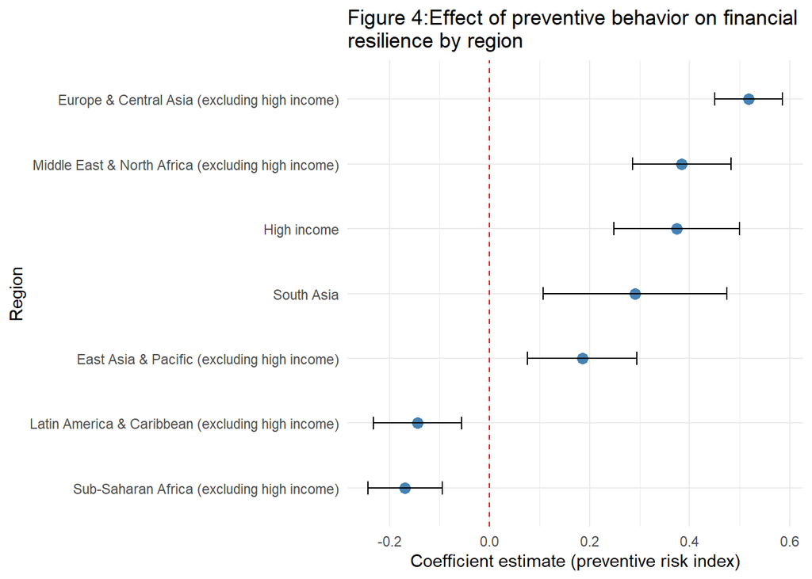

```r
library(broom.mixed)
library(ggplot2)

# Fit a separate model for each region using the best model variables
region_models <- dataset_clean %>%
  group_by(regionwb) %>%
  group_modify(~ tidy(lm(
    as.numeric(fin24b_ord) ~ preventive_risk_index + educ,
    data = .x
  ), conf.int = TRUE)) %>%
  filter(term == "preventive_risk_index")

# Create the forest plot
ggplot(region_models, aes(x = estimate, y = reorder(regionwb, estimate))) +
  geom_point(size = 3, color = "steelblue") +
  geom_errorbarh(aes(xmin = conf.low, xmax = conf.high), height = 0.2) +
  geom_vline(xintercept = 0, linetype = "dashed", color = "red") +
  labs(
    title = "Figure 4:Effect of preventive behavior on financial\nresilience by region",
    x = "Coefficient estimate (preventive risk index)",
    y = "Region"
  ) +
  theme_minimal()
```

The forest plot (Figure 4) reveals that the effect of preventive behavior on financial resilience is not the same across all regions. In Europe & Central Asia, the effect is the strongest and most positive, meaning that households with higher preventive behavior are significantly more resilient in this region. Middle East & North Africa, High income countries, and South Asia also show a clear positive effect, though slightly smaller. East Asia & Pacific shows a weaker but still positive effect. In contrast, Latin America & Caribbean and Sub-Saharan Africa show a negative effect, meaning that preventive behavior is actually associated with lower financial resilience in these regions. This surprising result may be explained by the fact that in these regions, households that save or pay for insurance are not necessarily better protected, possibly because financial products are less accessible or less effective.

## Sensitivity analyses

At this stage, we have presented our main results. However, it is important to check whether these results are stable. For this reason, we now perform sensitivity analyses. The goal is to see if our results remain the same when we change some elements of the model. We test different specifications and use alternative versions of the data. This allows us to ensure that our results are not driven by a specific choice, but are robust.

First, we test a different model by using a logistic regression. To do this, we transform financial resilience into a binary variable. Individuals who can cover their expenses for more than one month (categories “about two months” and “more than two months”) are classified as “resilient”, while those who cannot (categories “less than two weeks” and “about one month”) are classified as “not resilient”.

The goal is to see whether our results remain similar when we change the model and the data. This helps ensure that our findings are not driven by a specific choice, but are robust.

```r
# Transform fin24b into a binary variable
dataset <- dataset %>%
  mutate(
    fin24b_binary = case_when(
      fin24b %in% c(1, 2) ~ 0,  # low resilience
      fin24b %in% c(3, 4) ~ 1,  # high resilience
      TRUE ~ NA_real_
    )
  )
# Keep only complete cases on the variables used in the main model
# This mirrors the dataset used in the main analysis
dataset_original <- dataset %>%
  filter(!is.na(fin24b) & !is.na(fin24b_binary) & !is.na(preventive_risk_index) & !is.na(educ)& !is.na(female)& !is.na(age)& !is.na(inc_q)& !is.na(regionwb))
```

Deleting missing values can introduce bias if the missing data are not random. When we remove these observations, we may lose useful information. As a result, our estimates may be less accurate. To address this issue, we use an imputation method. In practice, we replace the missing values with plausible values based on the information available in the data. In this analysis, we use one imputed dataset (m = 1). This means that we create a single completed version of the dataset where missing values are filled in.

We then re-estimate our main model using this imputed dataset. This allows us to include observations that were previously removed. The goal is to check whether our main results remain similar. If the results do not change much, this suggests that missing values do not strongly affect our conclusions.

```r
library(dplyr)
library(mice)

# Imputed dataset
vars_to_impute <- dataset %>%
  select(fin24b, fin24b_binary, preventive_risk_index, female, age, educ, inc_q, regionwb)

imputed <- mice(vars_to_impute, m = 1, seed = 123)
dataset_imputed <- complete(imputed) %>%
  mutate(dataset_version = "imputed")

# Combine both
dataset_all <- bind_rows(dataset_original, dataset_imputed)
```

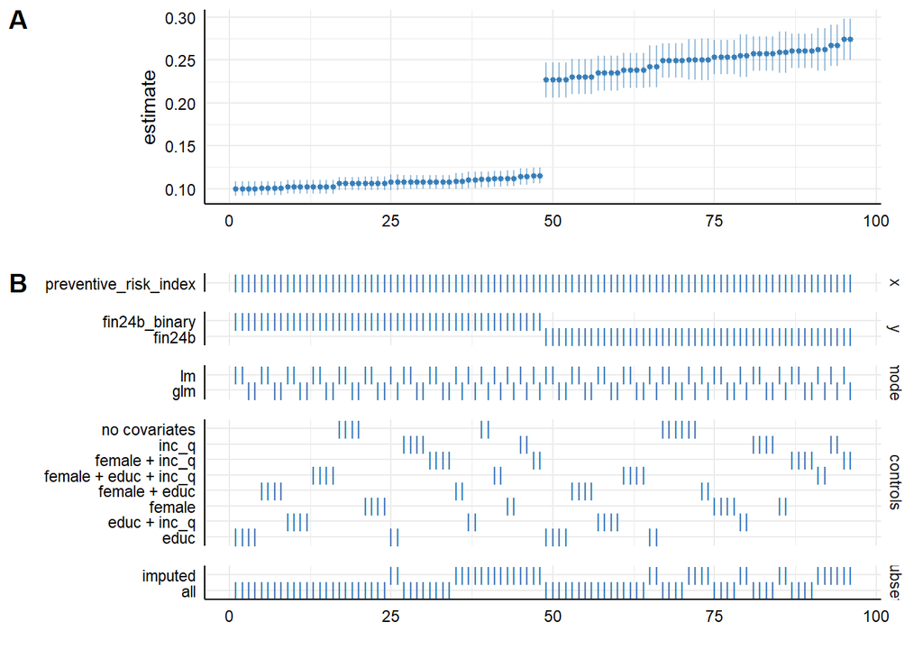

```r
library(specr)
library(dplyr)
setup_results <- setup(
  data     = dataset_all,
  y        = c("fin24b", "fin24b_binary"),  # vary the outcome
  x        = c("preventive_risk_index"),
  model    = c("lm", "glm"),                # lm for numeric, glm for binary
  controls = c("female", "educ", "inc_q"),
  subsets  = list(dataset_version = unique(dataset_all$dataset_version))
)
spec_results <- specr(setup_results)

plot(spec_results)
```

The specification curve shows how the effect of preventive financial behaviors changes across many different models. Each point represents one model, and the vertical axis shows the value of the coefficient. We can see that the coefficient is always positive. This means that preventive behaviors are always associated with higher financial resilience. This result remains the same across all specifications.

At the same time, the size of the effect changes slightly. In some models, the coefficient is around 0.10, while in others it is closer to 0.25. This variation comes from differences in the model. For example, we change the type of model, the control variables, and the version of the dataset. Moreover, the results are very similar when we use the original dataset and the imputed dataset. This suggests that missing values do not strongly affect the results.

In addition, we find a positive effect both with the linear model and with the logistic regression. This shows that the result does not depend on the choice of model.

Overall, the results are stable and consistent. Preventive financial behaviors have a positive effect on financial resilience in all cases. This confirms that our main finding is robust.

```r
library(knitr)
library(dplyr)

# Extract main results
results_table <- as.data.frame(spec_results) %>%
  select(model, controls, dataset_version, estimate, std.error) %>%
  head(10)

kable(
  results_table,
  caption = "Table 6: Selected specification results"
)
```

Table 6: Selected specification results

| model | controls | dataset_version | estimate | std.error |
| --- | --- | --- | --- | --- |
| lm | no covariates | NA | 0.2494348 | 0.0101482 |
| lm | no covariates | imputed | 0.2505615 | 0.0121281 |
| lm | no covariates | NA | 0.2494348 | 0.0101482 |
| lm | female | NA | 0.2531704 | 0.0101850 |
| lm | female | imputed | 0.2590786 | 0.0121781 |
| lm | female | NA | 0.2531704 | 0.0101850 |
| lm | educ | NA | 0.2267224 | 0.0103671 |
| lm | educ | imputed | 0.2424910 | 0.0124215 |
| lm | educ | NA | 0.2267224 | 0.0103671 |
| lm | inc_q | NA | 0.2573184 | 0.0102679 |

The specification curve analysis is based on 96 different model specifications. This means that we test many combinations of models, control variables, and dataset versions. This provides a rich and comprehensive analysis of the relationship between preventive financial behavior and financial resilience.

Across all these specifications, the coefficient of preventive financial behavior remains positive. The estimates range from 0.10 to 0.27, with a median value of 0.17. Even in the lowest case, where the coefficient is around 0.10, the effect remains positive. In the highest case, around 0.27, the effect is stronger, but still consistent with the same interpretation. Also at no point does the coefficient become negative. This means that preventive financial behavior is always associated with higher financial resilience.

We also compare results using the original dataset and the imputed dataset. The number of observations differs across these two versions, as the original dataset excludes missing values while the imputed dataset retains them. Despite this difference, the estimated effects remain very similar. This suggests that missing values do not drive the main results.

Finally, looking at individual models confirms this pattern. For example, even in a simple model without control variables, the coefficient is around 0.25. When we include control variables such as gender, or when we use the imputed dataset, the coefficient remains close, around 0.26. This shows that the result does not depend on the inclusion of controls or on the treatment of missing values.

Overall, the results are stable across all specifications. The effect remains positive and relatively consistent in magnitude. This provides strong evidence that preventive financial behaviors are positively associated with financial resilience.